# Análise dos Arquivos de Final de Curso

Bruno Cesar Pasquini

06/09/2020

# Procurando a melhor base de dados para a análise.

Para decidir qual dos arquivos irei utilizar para o trabalho final de conclusão de curso.

Primeiro vamos ver quais são os arquivos disponíveis para a análise:

```r
dir("data")
```

```
##  [1] "ames.rds"               "cetesb.rds"             "covid.rds"
##  [4] "credito.rds"            "dados_sinesp.rds"       "imdb.rds"
##  [7] "imdb_por_ano"           "pokemon.rds"            "rick_and_morty.rds"
## [10] "rick_and_morty_raw.rds" "ssp.rds"
```

## Bases Ames

### Base Ames fornecida no curso R para Ciência de Dados II

Olhando a base de dados das casas vendidas na cidade de Ames, Iowa, Estados Unidos

```r
ames %>%
   glimpse()
```

```
## Rows: 2,930
## Columns: 77
## $ lote_fachada                   <int> 141, 80, 81, 93, 74, 78, 41, 43, 39,...
## $ lote_area                      <int> 31770, 11622, 14267, 11160, 13830, 9...
## $ lote_formato                   <chr> "IR1", "Reg", "IR1", "Reg", "IR1", "...
## $ lote_config                    <chr> "Corner", "Inside", "Corner", "Corne...
## $ terreno_contorno               <chr> "Lvl", "Lvl", "Lvl", "Lvl", "Lvl", "...
## $ terreno_declive                <chr> "Gtl", "Gtl", "Gtl", "Gtl", "Gtl", "...
## $ rua_tipo                       <chr> "Pave", "Pave", "Pave", "Pave", "Pav...
## $ beco_tipo                      <chr> NA, NA, NA, NA, NA, NA, NA, NA, NA, ...
## $ utilidades                     <chr> "AllPub", "AllPub", "AllPub", "AllPu...
## $ vizinhanca                     <chr> "NAmes", "NAmes", "NAmes", "NAmes", ...
## $ moradia_tipo                   <chr> "1Fam", "1Fam", "1Fam", "1Fam", "1Fa...
## $ moradia_estilo                 <chr> "1Story", "1Story", "1Story", "1Stor...
## $ moradia_class                  <chr> "020", "020", "020", "020", "060", "...
```

[output cut: 64 more lines]

### Bases Ames Originais

```r
AmesHousing::ames_geo %>%
   glimpse()
```

```
## Rows: 2,932
## Columns: 3
## $ PID       <chr> "0526301100", "0526350040", "0526351010", "0526353030", "...
## $ Longitude <dbl> -93.61975, -93.61976, -93.61939, -93.61732, -93.63893, -9...
## $ Latitude  <dbl> 42.05403, 42.05301, 42.05266, 42.05125, 42.06090, 42.0607...
```

```r
AmesHousing::ames_raw %>%
   glimpse()
```

```
## Rows: 2,930
## Columns: 82
## $ Order             <int> 1, 2, 3, 4, 5, 6, 7, 8, 9, 10, 11, 12, 13, 14, 15...
## $ PID               <chr> "0526301100", "0526350040", "0526351010", "052635...
## $ `MS SubClass`     <chr> "020", "020", "020", "020", "060", "060", "120", ...
## $ `MS Zoning`       <chr> "RL", "RH", "RL", "RL", "RL", "RL", "RL", "RL", "...
## $ `Lot Frontage`    <int> 141, 80, 81, 93, 74, 78, 41, 43, 39, 60, 75, NA, ...
## $ `Lot Area`        <int> 31770, 11622, 14267, 11160, 13830, 9978, 4920, 50...
## $ Street            <chr> "Pave", "Pave", "Pave", "Pave", "Pave", "Pave", "...
## $ Alley             <chr> NA, NA, NA, NA, NA, NA, NA, NA, NA, NA, NA, NA, N...
## $ `Lot Shape`       <chr> "IR1", "Reg", "IR1", "Reg", "IR1", "IR1", "Reg", ...
## $ `Land Contour`    <chr> "Lvl", "Lvl", "Lvl", "Lvl", "Lvl", "Lvl", "Lvl", ...
## $ Utilities         <chr> "AllPub", "AllPub", "AllPub", "AllPub", "AllPub",...
## $ `Lot Config`      <chr> "Corner", "Inside", "Corner", "Corner", "Inside",...
## $ `Land Slope`      <chr> "Gtl", "Gtl", "Gtl", "Gtl", "Gtl", "Gtl", "Gtl", ...
```

[output cut: 69 more lines]

## Base Cetesb

Olhando a base de dados de concentração horária de alguns poluentes em algumas estações de monitoramento da região metropolitana de São Paulo

```r
cetesb %>%
   glimpse()
```

```
## Rows: 1,197,120
## Columns: 7
## $ estacao_cetesb <chr> "Congonhas", "Congonhas", "Congonhas", "Congonhas", ...
## $ poluente       <chr> "CO", "CO", "CO", "CO", "CO", "CO", "CO", "CO", "CO"...
## $ data           <date> 2017-01-01, 2017-01-01, 2017-01-01, 2017-01-01, 201...
## $ hora           <dbl> 1, 2, 3, 4, 5, 6, 7, 8, 9, 10, 11, 12, 13, 14, 15, 1...
## $ concentracao   <dbl> 0.4, 0.3, 0.6, 0.6, 0.6, 0.6, 0.5, 0.5, 0.4, 0.4, 0....
## $ lat            <dbl> -23.61632, -23.61632, -23.61632, -23.61632, -23.6163...
## $ long           <dbl> -46.66345, -46.66345, -46.66345, -46.66345, -46.6634...
```

Olhando um pouco mais…

```r
cetesb %>%
   select(estacao_cetesb, lat, long) %>%
   distinct()
```

```
## # A tibble: 12 x 3
##    estacao_cetesb       lat  long
##    <chr>              <dbl> <dbl>
##  1 Congonhas          -23.6 -46.7
##  2 Osasco             -23.5 -46.8
##  3 Ibirapuera         -23.6 -46.7
##  4 Mooca              -23.5 -46.6
##  5 Pinheiros          -23.6 -46.7
##  6 Parque D.Pedro II  -23.5 -46.6
##  7 São Caetano do Sul -23.6 -46.6
##  8 Santo Amaro        -23.7 -46.7
##  9 Parelheiros        -23.8 -46.7
## 10 IPEN-USP           -23.6 -46.7
## 11 Nossa Senhora do Ó -23.5 -46.7
## 12 Santana            -23.5 -46.6
```

```r
cetesb %>%
   select(poluente) %>%
   distinct()
```

```
## # A tibble: 5 x 1
##   poluente
##   <chr>
## 1 CO
## 2 NO
## 3 NO2
## 4 MP10
## 5 O3
```

```r
cetesb %>%
   select(data, hora) %>%
   head(n = 10)
```

```
## # A tibble: 10 x 2
##    data        hora
##    <date>     <dbl>
##  1 2017-01-01     1
##  2 2017-01-01     2
##  3 2017-01-01     3
##  4 2017-01-01     4
##  5 2017-01-01     5
##  6 2017-01-01     6
##  7 2017-01-01     7
##  8 2017-01-01     8
##  9 2017-01-01     9
## 10 2017-01-01    10
```

```r
cetesb %>%
   select(data, hora) %>%
   tail(n = 10)
```

```
## # A tibble: 10 x 2
##    data        hora
##    <date>     <dbl>
##  1 2020-05-31    15
##  2 2020-05-31    16
##  3 2020-05-31    17
##  4 2020-05-31    18
##  5 2020-05-31    19
##  6 2020-05-31    20
##  7 2020-05-31    21
##  8 2020-05-31    22
##  9 2020-05-31    23
## 10 2020-05-31    24
```

### Olhando um poluente em específico

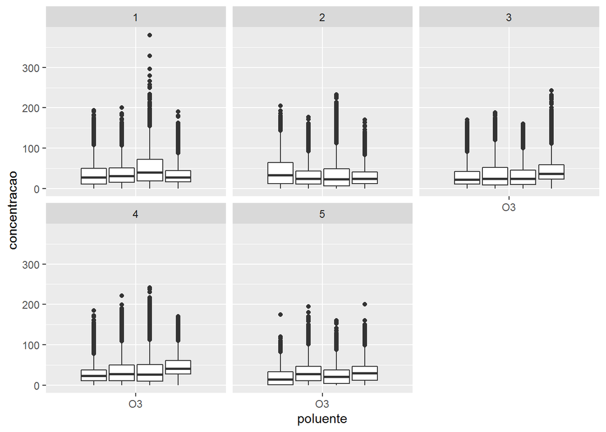

```r
cetesb %>%
   filter(
      poluente == "O3",
      lubridate::month(data) <= 5
   ) %>%
   select(
      poluente,
      data,
      concentracao
   ) %>%
   mutate(
      ano = lubridate::year(data),
      mes = lubridate::month(data)
   ) %>%
   group_by(
      ano,
      mes
   ) %>%
   ggplot() +
   geom_boxplot(
      aes(
         x = poluente,
         y = concentracao,
         group = ano
         )
      ) +
   facet_wrap(~ mes)
```

## Base COVID

### Base COVID-19 fornecida no curso R para Ciência de Dados II

```r
covid %>%
   glimpse()
```

```
## Rows: 438,835
## Columns: 21
## $ regiao                <chr> "Brasil", "Brasil", "Brasil", "Brasil", "Bras...
## $ estado                <chr> NA, NA, NA, NA, NA, NA, NA, NA, NA, NA, NA, N...
## $ municipio             <chr> NA, NA, NA, NA, NA, NA, NA, NA, NA, NA, NA, N...
## $ coduf                 <chr> "76", "76", "76", "76", "76", "76", "76", "76...
## $ codmun                <dbl> NA, NA, NA, NA, NA, NA, NA, NA, NA, NA, NA, N...
## $ codRegiaoSaude        <dbl> NA, NA, NA, NA, NA, NA, NA, NA, NA, NA, NA, N...
## $ nomeRegiaoSaude       <chr> NA, NA, NA, NA, NA, NA, NA, NA, NA, NA, NA, N...
## $ data                  <date> 2020-02-25, 2020-02-26, 2020-02-27, 2020-02-...
## $ semanaEpi             <dbl> 9, 9, 9, 9, 9, 10, 10, 10, 10, 10, 10, 10, 11...
## $ populacaoTCU2019      <dbl> 210147125, 210147125, 210147125, 210147125, 2...
## $ casosAcumulado        <dbl> 0, 1, 1, 1, 2, 2, 2, 2, 3, 7, 13, 19, 25, 25,...
## $ casosNovos            <dbl> 0, 1, 0, 0, 1, 0, 0, 0, 1, 4, 6, 6, 6, 0, 9, ...
## $ obitosAcumulado       <dbl> 0, 0, 0, 0, 0, 0, 0, 0, 0, 0, 0, 0, 0, 0, 0, ...
## $ obitosNovos           <dbl> 0, 0, 0, 0, 0, 0, 0, 0, 0, 0, 0, 0, 0, 0, 0, ...
## $ Recuperadosnovos      <dbl> NA, NA, NA, NA, NA, NA, NA, NA, NA, NA, NA, N...
## $ emAcompanhamentoNovos <dbl> NA, NA, NA, NA, NA, NA, NA, NA, NA, NA, NA, N...
## $ eh_capital            <lgl> FALSE, FALSE, FALSE, FALSE, FALSE, FALSE, FAL...
## $ obitosAcumulado_log2  <dbl> -1.000000, -1.000000, -1.000000, -1.000000, -...
## $ obitosNovos_log2      <dbl> -1.000000, -1.000000, -1.000000, -1.000000, -...
## $ lat                   <dbl> NA, NA, NA, NA, NA, NA, NA, NA, NA, NA, NA, N...
## $ lon                   <dbl> NA, NA, NA, NA, NA, NA, NA, NA, NA, NA, NA, N...
```

Olhando um pouco mais, buscando algumas informações que não façam sentido…

```r
covid %>%
   group_by(regiao) %>%
   count() %>%
   arrange(desc(n))
```

```
## # A tibble: 6 x 2
## # Groups:   regiao [6]
##   regiao            n
##   <chr>         <int>
## 1 Nordeste     162036
## 2 Sudeste      117979
## 3 Sul           88545
## 4 Norte         38449
## 5 Centro-Oeste  31714
## 6 Brasil          112
```

```r
covid %>%
   group_by(municipio) %>%
   count() %>%
   arrange(desc(n))
```

```
## # A tibble: 4,531 x 2
## # Groups:   municipio [4,531]
##    municipio         n
##    <chr>         <int>
##  1 <NA>           4675
##  2 Bom Jesus      2025
##  3 Bonito         1296
##  4 Planalto       1296
##  5 Santa Helena   1296
##  6 Santa Inês     1296
##  7 Santa Luzia    1296
##  8 São Francisco  1296
##  9 São Domingos   1215
## 10 Vera Cruz       972
## # ... with 4,521 more rows
```

```r
covid %>%
   group_by(codmun) %>%
   count() %>%
   arrange(desc(n))
```

```
## # A tibble: 4,777 x 2
## # Groups:   codmun [4,777]
##    codmun     n
##     <dbl> <int>
##  1     NA  3136
##  2 220190   405
##  3 240170   405
##  4 250220   405
##  5 280680   405
##  6 292895   405
##  7 420253   405
##  8 421610   405
##  9 430230   405
## 10 150160   324
## # ... with 4,767 more rows
```

Buscando o filtro que pareça fazer mais sentido…

```r
covid %>%
   filter(
      regiao != "Brasil",
      !is.na(municipio),
      !is.na(codmun)
   ) %>%
   glimpse()
```

```
## Rows: 434,160
## Columns: 21
## $ regiao                <chr> "Norte", "Norte", "Norte", "Norte", "Norte", ...
## $ estado                <chr> "RO", "RO", "RO", "RO", "RO", "RO", "RO", "RO...
## $ municipio             <chr> "Alta Floresta D'Oeste", "Alta Floresta D'Oes...
## $ coduf                 <chr> "11", "11", "11", "11", "11", "11", "11", "11...
## $ codmun                <dbl> 110001, 110001, 110001, 110001, 110001, 11000...
## $ codRegiaoSaude        <dbl> 11005, 11005, 11005, 11005, 11005, 11005, 110...
## $ nomeRegiaoSaude       <chr> "ZONA DA MATA", "ZONA DA MATA", "ZONA DA MATA...
## $ data                  <date> 2020-03-27, 2020-03-28, 2020-03-29, 2020-03-...
## $ semanaEpi             <dbl> 13, 13, 14, 14, 14, 14, 14, 14, 14, 15, 15, 1...
## $ populacaoTCU2019      <dbl> 22945, 22945, 22945, 22945, 22945, 22945, 229...
## $ casosAcumulado        <dbl> 0, 0, 0, 0, 0, 0, 0, 0, 0, 0, 0, 0, 0, 0, 0, ...
## $ casosNovos            <dbl> 0, 0, 0, 0, 0, 0, 0, 0, 0, 0, 0, 0, 0, 0, 0, ...
## $ obitosAcumulado       <dbl> 0, 0, 0, 0, 0, 0, 0, 0, 0, 0, 0, 0, 0, 0, 0, ...
## $ obitosNovos           <dbl> 0, 0, 0, 0, 0, 0, 0, 0, 0, 0, 0, 0, 0, 0, 0, ...
## $ Recuperadosnovos      <dbl> NA, NA, NA, NA, NA, NA, NA, NA, NA, NA, NA, N...
## $ emAcompanhamentoNovos <dbl> NA, NA, NA, NA, NA, NA, NA, NA, NA, NA, NA, N...
## $ eh_capital            <lgl> FALSE, FALSE, FALSE, FALSE, FALSE, FALSE, FAL...
## $ obitosAcumulado_log2  <dbl> -1, -1, -1, -1, -1, -1, -1, -1, -1, -1, -1, -...
## $ obitosNovos_log2      <dbl> -1, -1, -1, -1, -1, -1, -1, -1, -1, -1, -1, -...
## $ lat                   <dbl> -12.47017, -12.47017, -12.47017, -12.47017, -...
## $ lon                   <dbl> -62.27467, -62.27467, -62.27467, -62.27467, -...
```

Achamos o melhor filtro… Vamos ver algumas coisas da base de dados…

```r
covid %>%
   filter(
      regiao != "Brasil",
      !is.na(municipio),
      !is.na(codmun)
   ) %>%
   select(data, where(is.numeric)) %>%
   summary()
```

```
##       data                codmun       codRegiaoSaude    semanaEpi
##  Min.   :2020-03-27   Min.   :110001   Min.   :11001   Min.   :13
##  1st Qu.:2020-04-16   1st Qu.:250214   1st Qu.:25002   1st Qu.:16
##  Median :2020-05-06   Median :312925   Median :31032   Median :19
##  Mean   :2020-05-06   Mean   :317893   Mean   :31666   Mean   :19
##  3rd Qu.:2020-05-26   3rd Qu.:411005   3rd Qu.:41010   3rd Qu.:22
##  Max.   :2020-06-15   Max.   :530010   Max.   :53001   Max.   :25
##
##  populacaoTCU2019   casosAcumulado       casosNovos       obitosAcumulado
##  Min.   :       8   Min.   :    0.00   Min.   :-349.000   Min.   :   0.000
##  1st Qu.:    6579   1st Qu.:    0.00   1st Qu.:   0.000   1st Qu.:   0.000
##  Median :   13996   Median :    1.00   Median :   0.000   Median :   0.000
##  Mean   :   42220   Mean   :   50.86   Mean   :   2.299   Mean   :   2.969
##  3rd Qu.:   28647   3rd Qu.:    7.00   3rd Qu.:   0.000   3rd Qu.:   0.000
##  Max.   :12252023   Max.   :93448.00   Max.   :3455.000   Max.   :5652.000
##
##   obitosNovos       Recuperadosnovos emAcompanhamentoNovos obitosAcumulado_log2
##  Min.   :-36.0000   Min.   : NA      Min.   : NA           Min.   :-1.0000
##  1st Qu.:  0.0000   1st Qu.: NA      1st Qu.: NA           1st Qu.:-1.0000
##  Median :  0.0000   Median : NA      Median : NA           Median :-1.0000
##  Mean   :  0.1153   Mean   :NaN      Mean   :NaN           Mean   :-0.5292
##  3rd Qu.:  0.0000   3rd Qu.: NA      3rd Qu.: NA           3rd Qu.:-1.0000
##  Max.   :227.0000   Max.   : NA      Max.   : NA           Max.   :12.4645
##                     NA's   :434160   NA's   :434160
##  obitosNovos_log2       lat               lon
##  Min.   :-1.0000   Min.   :-33.164   Min.   :-73.44
##  1st Qu.:-1.0000   1st Qu.:-22.719   1st Qu.:-50.62
##  Median :-1.0000   Median :-16.386   Median :-46.19
##  Mean   :-0.9416   Mean   :-15.775   Mean   :-45.89
##  3rd Qu.:-1.0000   3rd Qu.: -7.667   3rd Qu.:-40.37
##  Max.   : 7.8265   Max.   :  4.684   Max.   :-32.43
##                    NA's   :486       NA's   :486
```

Quais são as localidades para as quais não temos a localização do centróide?

```r
covid %>%
   filter(
      regiao != "Brasil",
      !is.na(municipio),
      !is.na(codmun),
      is.na(lat) | is.na(lon)
   ) %>%
   group_by(municipio, estado) %>%
   count()
```

```
## # A tibble: 6 x 3
## # Groups:   municipio, estado [6]
##   municipio         estado     n
##   <chr>             <chr>  <int>
## 1 Joca Claudino     PB        81
## 2 Mojuí dos Campos  PA        81
## 3 Paraíso das Águas MS        81
## 4 Pescaria Brava    SC        81
## 5 Pinto Bandeira    RS        81
## 6 Serra Caiada      RN        81
```

### Base COVID-19 obtida atraves do pacote datacovidbr

```r
datacovidbr::brasilio() %>%
   filter(
      place_type == "city",
      !is.na(city),
      !is.na(city_ibge_code)
   ) %>%
   glimpse()
```

```
## Rows: 629,008
## Columns: 12
## $ date                           <date> 2020-09-04, 2020-09-03, 2020-09-01,...
## $ state                          <chr> "AC", "AC", "AC", "AC", "AC", "AC", ...
## $ city                           <chr> "Acrelândia", "Acrelândia", "Acrelân...
## $ place_type                     <chr> "city", "city", "city", "city", "cit...
## $ confirmed                      <dbl> 432, 432, 428, 428, 428, 428, 427, 4...
## $ deaths                         <dbl> 9, 9, 8, 8, 8, 8, 8, 8, 8, 8, 8, 8, ...
## $ order_for_place                <dbl> 154, 153, 152, 151, 150, 149, 148, 1...
## $ is_last                        <lgl> TRUE, FALSE, FALSE, FALSE, FALSE, FA...
## $ estimated_population_2019      <dbl> 15256, 15256, 15256, 15256, 15256, 1...
## $ city_ibge_code                 <dbl> 1200013, 1200013, 1200013, 1200013, ...
## $ confirmed_per_100k_inhabitants <dbl> 2831.673, 2831.673, 2805.454, 2805.4...
## $ death_rate                     <dbl> 0.0208, 0.0208, 0.0187, 0.0187, 0.01...
```

```r
datacovidbr::brMinisterioSaude() %>%
   filter(
      regiao != "Brasil",
      !is.na(municipio),
      !is.na(codmun)
   ) %>%
   glimpse()
```

```
## Rows: 912,004
## Columns: 17
## $ regiao                   <chr> "Norte", "Norte", "Norte", "Norte", "Norte...
## $ estado                   <chr> "RO", "RO", "RO", "RO", "RO", "RO", "RO", ...
## $ municipio                <chr> "Alta Floresta D'Oeste", "Alta Floresta D'...
## $ coduf                    <int> 11, 11, 11, 11, 11, 11, 11, 11, 11, 11, 11...
## $ codmun                   <int> 110001, 110001, 110001, 110001, 110001, 11...
## $ codRegiaoSaude           <chr> "11005", "11005", "11005", "11005", "11005...
## $ nomeRegiaoSaude          <chr> "ZONA DA MATA", "ZONA DA MATA", "ZONA DA M...
## $ date                     <date> 2020-03-27, 2020-03-28, 2020-03-29, 2020-...
## $ semanaEpi                <int> 13, 13, 14, 14, 14, 14, 14, 14, 14, 15, 15...
## $ populacaoTCU2019         <int> 22945, 22945, 22945, 22945, 22945, 22945, ...
## $ casosAcumulado           <int> 0, 0, 0, 0, 0, 0, 0, 0, 0, 0, 0, 0, 0, 0, ...
## $ casosNovos               <int> 0, 0, 0, 0, 0, 0, 0, 0, 0, 0, 0, 0, 0, 0, ...
## $ obitosAcumulado          <int> 0, 0, 0, 0, 0, 0, 0, 0, 0, 0, 0, 0, 0, 0, ...
## $ obitosNovos              <int> 0, 0, 0, 0, 0, 0, 0, 0, 0, 0, 0, 0, 0, 0, ...
## $ Recuperadosnovos         <int> NA, NA, NA, NA, NA, NA, NA, NA, NA, NA, NA...
## $ emAcompanhamentoNovos    <int> NA, NA, NA, NA, NA, NA, NA, NA, NA, NA, NA...
## $ `interior/metropolitana` <chr> "0", "0", "0", "0", "0", "0", "0", "0", "0...
```

```r
# datacovidbr::CSSEGISandData() %>%
#    glimpse()
```

Esta última base parece ser a base da qual foi extraída a base do curso…

```r
datacovidbr::brasilio() %>%
   filter(
      place_type == "city",
      !is.na(city),
      !is.na(city_ibge_code)
   ) %>%
   select(date, where(is.numeric)) %>%
   summary()
```

```
##       date              confirmed            deaths        order_for_place
##  Min.   :2020-02-25   Min.   :     0.0   Min.   :    0.0   Min.   :  1.00
##  1st Qu.:2020-06-04   1st Qu.:     5.0   1st Qu.:    0.0   1st Qu.: 29.00
##  Median :2020-07-07   Median :    29.0   Median :    1.0   Median : 58.00
##  Mean   :2020-07-03   Mean   :   335.8   Mean   :   12.6   Mean   : 61.23
##  3rd Qu.:2020-08-05   3rd Qu.:   141.0   3rd Qu.:    3.0   3rd Qu.: 90.00
##  Max.   :2020-09-06   Max.   :266232.0   Max.   :11666.0   Max.   :183.00
##
##  estimated_population_2019 city_ibge_code    confirmed_per_100k_inhabitants
##  Min.   :     781          Min.   :1100015   Min.   :    0.008
##  1st Qu.:    6533          1st Qu.:2505709   1st Qu.:   53.658
##  Median :   14385          Median :3141702   Median :  259.067
##  Mean   :   49599          Mean   :3205879   Mean   :  630.744
##  3rd Qu.:   31984          3rd Qu.:4112306   3rd Qu.:  820.082
##  Max.   :12252023          Max.   :5300108   Max.   :16397.621
##                                              NA's   :12235
##    death_rate
##  Min.   :0.00000
##  1st Qu.:0.00000
##  Median :0.00920
##  Mean   :0.04057
##  3rd Qu.:0.03700
##  Max.   :1.00000
##
```

```r
datacovidbr::brMinisterioSaude() %>%
   filter(
      regiao != "Brasil",
      !is.na(municipio),
      !is.na(codmun)
   ) %>%
   select(date, where(is.numeric)) %>%
   summary()
```

```
##       date                coduf           codmun         semanaEpi
##  Min.   :2020-03-27   Min.   :11.00   Min.   :110001   Min.   :13.00
##  1st Qu.:2020-05-06   1st Qu.:25.00   1st Qu.:251207   1st Qu.:19.00
##  Median :2020-06-16   Median :31.00   Median :314600   Median :25.00
##  Mean   :2020-06-16   Mean   :32.36   Mean   :325209   Mean   :24.93
##  3rd Qu.:2020-07-27   3rd Qu.:41.00   3rd Qu.:411880   3rd Qu.:31.00
##  Max.   :2020-09-06   Max.   :53.00   Max.   :530010   Max.   :37.00
##
##  populacaoTCU2019   casosAcumulado     casosNovos        obitosAcumulado
##  Min.   :     781   Min.   :     0   Min.   :-2407.000   Min.   :    0.000
##  1st Qu.:    5474   1st Qu.:     0   1st Qu.:    0.000   1st Qu.:    0.000
##  Median :   11655   Median :     9   Median :    0.000   Median :    0.000
##  Mean   :   37785   Mean   :   248   Mean   :    4.518   Mean   :    9.189
##  3rd Qu.:   25501   3rd Qu.:    77   3rd Qu.:    1.000   3rd Qu.:    2.000
##  Max.   :12252023   Max.   :267767   Max.   : 7063.000   Max.   :11731.000
##
##   obitosNovos        Recuperadosnovos emAcompanhamentoNovos
##  Min.   :-238.0000   Min.   : NA      Min.   : NA
##  1st Qu.:   0.0000   1st Qu.: NA      1st Qu.: NA
##  Median :   0.0000   Median : NA      Median : NA
##  Mean   :   0.1387   Mean   :NaN      Mean   :NaN
##  3rd Qu.:   0.0000   3rd Qu.: NA      3rd Qu.: NA
##  Max.   : 245.0000   Max.   : NA      Max.   : NA
##                      NA's   :912004   NA's   :912004
```

## Base Credito

```r
credito %>%
   glimpse()
```

```
## Rows: 4,454
## Columns: 14
## $ status           <chr> "bom", "bom", "ruim", "bom", "bom", "bom", "bom", ...
## $ tempo_empresa    <int> 9, 17, 10, 0, 0, 1, 29, 9, 0, 0, 6, 7, 8, 19, 0, 0...
## $ moradia          <chr> "alugada", "alugada", "própria", "alugada", "aluga...
## $ tempo_emprestimo <int> 60, 60, 36, 60, 36, 60, 60, 12, 60, 48, 48, 36, 60...
## $ idade            <int> 30, 58, 46, 24, 26, 36, 44, 27, 32, 41, 34, 29, 30...
## $ estado_civil     <chr> "casada(o)", "viúva(o)", "casada(o)", "solteira(o)...
## $ registros        <chr> "não", "não", "sim", "não", "não", "não", "não", "...
## $ trabalho         <chr> "autônomo", "fixo", "autônomo", "fixo", "fixo", "f...
## $ despesas         <int> 73, 48, 90, 63, 46, 75, 75, 35, 90, 90, 60, 60, 75...
## $ renda            <int> 129, 131, 200, 182, 107, 214, 125, 80, 107, 80, 12...
## $ ativos           <int> 0, 0, 3000, 2500, 0, 3500, 10000, 0, 15000, 0, 400...
## $ dividas          <int> 0, 0, 0, 0, 0, 0, 0, 0, 0, 0, 0, 0, 2500, 260, 0, ...
## $ valor_emprestimo <int> 800, 1000, 2000, 900, 310, 650, 1600, 200, 1200, 1...
## $ preco_do_bem     <int> 846, 1658, 2985, 1325, 910, 1645, 1800, 1093, 1957...
```

```r
credito %>%
   count(status)
```

```
##   status    n
## 1    bom 3200
## 2   ruim 1254
```

```r
credito %>%
   count(moradia)
```

```
##   moradia    n
## 1 alugada  973
## 2  outras  319
## 3    pais  783
## 4    priv  246
## 5 própria 2107
## 6    <NA>   26
```

```r
credito %>%
   count(estado_civil)
```

```
##    estado_civil    n
## 1     casada(o) 3241
## 2 divorciada(o)   38
## 3   separada(o)  130
## 4   solteira(o)  977
## 5      viúva(o)   67
## 6          <NA>    1
```

```r
credito %>%
   count(registros)
```

```
##   registros    n
## 1       não 3681
## 2       sim  773
```

```r
credito %>%
   count(trabalho)
```

```
##       trabalho    n
## 1     autônomo 1024
## 2         fixo 2805
## 3 meio período  452
## 4       outros  171
## 5         <NA>    2
```

```r
credito %>%
   count(status, registros)
```

```
##   status registros    n
## 1    bom       não 2856
## 2    bom       sim  344
## 3   ruim       não  825
## 4   ruim       sim  429
```

Pensando em algumas variáveis que são texto…

```r
credito %>%
   mutate(
      status = as.factor(status),
      moradia = as.factor(moradia),
      estado_civil = as.factor(estado_civil),
      registros = as.factor(registros),
      trabalho = as.factor(trabalho)
   ) %>%
   glimpse()
```

```
## Rows: 4,454
## Columns: 14
## $ status           <fct> bom, bom, ruim, bom, bom, bom, bom, bom, bom, ruim...
## $ tempo_empresa    <int> 9, 17, 10, 0, 0, 1, 29, 9, 0, 0, 6, 7, 8, 19, 0, 0...
## $ moradia          <fct> alugada, alugada, própria, alugada, alugada, própr...
## $ tempo_emprestimo <int> 60, 60, 36, 60, 36, 60, 60, 12, 60, 48, 48, 36, 60...
## $ idade            <int> 30, 58, 46, 24, 26, 36, 44, 27, 32, 41, 34, 29, 30...
## $ estado_civil     <fct> casada(o), viúva(o), casada(o), solteira(o), solte...
## $ registros        <fct> não, não, sim, não, não, não, não, não, não, não, ...
## $ trabalho         <fct> autônomo, fixo, autônomo, fixo, fixo, fixo, fixo, ...
## $ despesas         <int> 73, 48, 90, 63, 46, 75, 75, 35, 90, 90, 60, 60, 75...
## $ renda            <int> 129, 131, 200, 182, 107, 214, 125, 80, 107, 80, 12...
## $ ativos           <int> 0, 0, 3000, 2500, 0, 3500, 10000, 0, 15000, 0, 400...
## $ dividas          <int> 0, 0, 0, 0, 0, 0, 0, 0, 0, 0, 0, 0, 2500, 260, 0, ...
## $ valor_emprestimo <int> 800, 1000, 2000, 900, 310, 650, 1600, 200, 1200, 1...
## $ preco_do_bem     <int> 846, 1658, 2985, 1325, 910, 1645, 1800, 1093, 1957...
```

### Olhando o Valor de Informação nas variáveis nesta base…

Neste caso a variável resposta tem que ser numérica…

```r
credito_iv <- credito %>%
   mutate(
      tp_cliente = ifelse(
         test = status == "bom",
         yes = 0L,
         no = 1L
      ),
      moradia = as.factor(moradia),
      estado_civil = as.factor(estado_civil),
      registros = as.factor(registros),
      trabalho = as.factor(trabalho),
      status = as.integer(tp_cliente)
   ) %>%
   select(-tp_cliente) %>%
   Information::create_infotables(
      y = "status",
      bins = 10,
      parallel = TRUE
)

print(credito_iv$Summary,
      row.names = FALSE)
```

```
##          Variable         IV
##     tempo_empresa 0.50493773
##             renda 0.39842535
##         registros 0.34313582
##          trabalho 0.33051978
##            ativos 0.25099638
##           moradia 0.24904474
##  valor_emprestimo 0.12848741
##  tempo_emprestimo 0.07997258
##             idade 0.07510958
##          despesas 0.06370590
##      preco_do_bem 0.05803407
##      estado_civil 0.05611495
##           dividas 0.01673878
```

```r
# Arrumar a chamada da lista...
for (i in 1:length(credito_iv$Summary$Variable)) {
   if (credito_iv$Summary$IV[i] > 0) {
      print(credito_iv$Tables[credito_iv$Summary$Variable[i]],
            row.names = FALSE)
   }
}; rm(i)
```

```
## $tempo_empresa
##  tempo_empresa   N   Percent         WOE        IV
##          [0,0] 535 0.1201167  1.10543508 0.1710080
##          [1,1] 510 0.1145038  0.67652927 0.2298887
##          [2,2] 454 0.1019308  0.44239977 0.2515823
##          [3,4] 569 0.1277503 -0.01918581 0.2516291
##          [5,7] 584 0.1311181 -0.14361760 0.2542469
##          [8,9] 243 0.0545577 -0.65788326 0.2742660
##        [10,13] 564 0.1266278 -0.51504219 0.3038735
##        [14,19] 495 0.1111361 -0.97041264 0.3850493
##        [20,48] 500 0.1122586 -1.21673715 0.5049377
##
## $renda
##      renda   N    Percent        WOE        IV
##         NA 381 0.08554109  1.2168433 0.1482070
##     [6,66] 397 0.08913336  0.8511176 0.2221075
##    [67,82] 412 0.09250112  0.4104222 0.2389644
##    [83,99] 409 0.09182757  0.2509912 0.2450510
##  [100,109] 349 0.07835653 -0.1656240 0.2471208
##  [110,124] 462 0.10372699 -0.4014728 0.2623045
##  [125,139] 365 0.08194881 -0.3177127 0.2699794
##  [140,158] 453 0.10170633 -0.4999128 0.2924740
##  [159,184] 393 0.08823529 -0.7003623 0.3287358
##  [185,230] 425 0.09541985 -0.7931825 0.3777353
##  [231,959] 408 0.09160305 -0.5055715 0.3984254
##
## $registros
##  registros    N   Percent        WOE         IV
##        não 3681 0.8264481 -0.3049816 0.07155028
##        sim  773 0.1735519  1.1576276 0.34313582
##
## $trabalho
##      trabalho    N      Percent        WOE         IV
##          <NA>    2 0.0004490346  0.0000000 0.00000000
##      autônomo 1024 0.2299057027  0.2068150 0.01026066
##          fixo 2805 0.6297709924 -0.4076717 0.10516361
##  meio período  452 0.1014818141  1.3404342 0.31902445
##        outros  171 0.0383924562  0.5215911 0.33051978
##
## $ativos
```

[output cut: 74 more lines]

```
##
## $estado_civil
##   estado_civil    N      Percent         WOE         IV
##           <NA>    1 0.0002245173  0.00000000 0.00000000
##      casada(o) 3241 0.7276605299 -0.13117904 0.01215577
##  divorciada(o)   38 0.0085316569  0.39781587 0.01361347
##    separada(o)  130 0.0291872474  0.90604071 0.04116770
##    solteira(o)  977 0.2193533902  0.25439326 0.05611343
##       viúva(o)   67 0.0150426583  0.01005034 0.05611495
##
## $dividas
##       dividas    N     Percent          WOE         IV
##            NA   18 0.004041311  1.892323813 0.01666064
##      [0,1172] 3986 0.894925909 -0.008993629 0.01673288
##  [1200,30000]  450 0.101032780 -0.007649241 0.01673878
```

### Árvore de decisão, um modelo simples e rápido…

```r
credito2 <- credito %>%
   select(status, as.character(credito_iv$Summary$Variable))

cred_arvore <- credito2 %>%
   rpart::rpart(formula = status ~ .)
```

Vamos dar uma olhada na árvore de decisão construída.

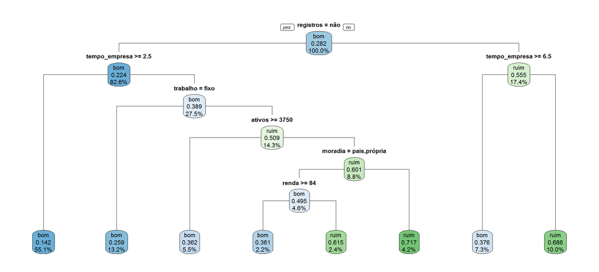

```r
rpart.plot::rpart.plot(
   x = cred_arvore,
   type = 1,
   extra = "auto",
   digits = 3
)
```

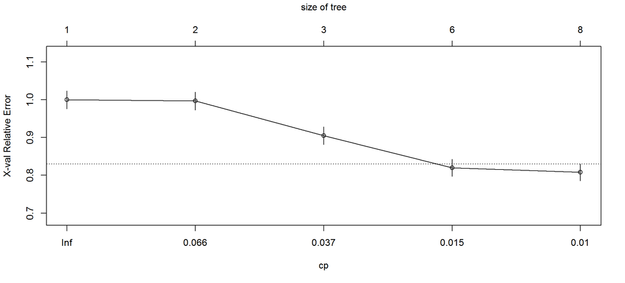

```r
rpart::plotcp(
   x = cred_arvore,
   minline = TRUE,
)
```

```r
rpart::rsq.rpart(x = cred_arvore)
```

```
##
## Classification tree:
## rpart::rpart(formula = status ~ ., data = .)
##
## Variables actually used in tree construction:
## [1] ativos        moradia       registros     renda         tempo_empresa
## [6] trabalho
##
## Root node error: 1254/4454 = 0.28154
##
## n= 4454
##
##         CP nsplit rel error  xerror     xstd
## 1 0.067783      0   1.00000 1.00000 0.023936
## 2 0.064593      1   0.93222 0.99681 0.023913
## 3 0.020999      2   0.86762 0.90510 0.023192
## 4 0.010766      5   0.80463 0.81978 0.022424
## 5 0.010000      7   0.78309 0.80781 0.022309
```

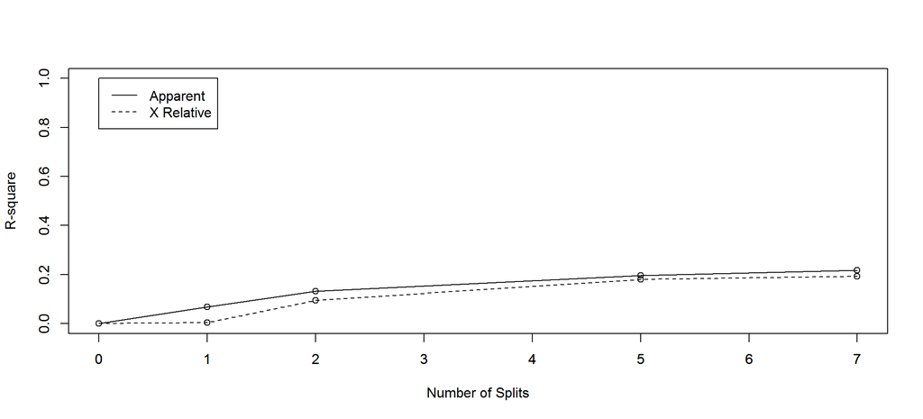

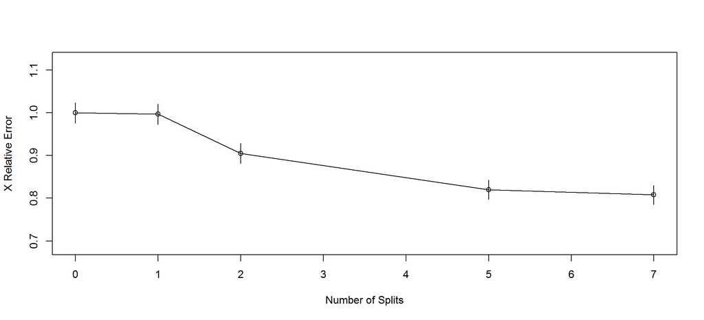

### Modelo de Regressão Logística, sem fazer **feature enginnering** nem separar a base em *treinamento* e *validação*…

```r
credito2 %>%
   filter(!is.na(status),
          !is.na(tempo_empresa),
          !is.na(renda),
          !is.na(registros),
          !is.na(trabalho),
          !is.na(ativos),
          !is.na(moradia),
          !is.na(valor_emprestimo),
          !is.na(tempo_emprestimo),
          !is.na(idade),
          !is.na(despesas),
          !is.na(preco_do_bem),
          !is.na(estado_civil),
          !is.na(dividas)
   ) %>%
   mutate(
      tp_cliente = ifelse(
         test = status == "bom",
         yes = 0L,
         no = 1L
      ),
      moradia = as.factor(moradia),
      estado_civil = as.factor(estado_civil),
      registros = as.factor(registros),
      trabalho = as.factor(trabalho),
      status = as.integer(tp_cliente)
   ) %>%
   select(-tp_cliente) -> credito3

cred_intercepto <- glm(
   formula = status ~ 1,
   family = binomial(link = "logit"),
   data = credito3
)
summary(cred_intercepto)
```

```
##
## Call:
## glm(formula = status ~ 1, family = binomial(link = "logit"),
##     data = credito3)
##
## Deviance Residuals:
##     Min       1Q   Median       3Q      Max
## -0.7642  -0.7642  -0.7642   1.6574   1.6574
##
## Coefficients:
##             Estimate Std. Error z value Pr(>|z|)
## (Intercept) -1.08144    0.03627  -29.82   <2e-16 ***
## ---
## Signif. codes:  0 '***' 0.001 '**' 0.01 '*' 0.05 '.' 0.1 ' ' 1
##
## (Dispersion parameter for binomial family taken to be 1)
##
##     Null deviance: 4549.5  on 4019  degrees of freedom
## Residual deviance: 4549.5  on 4019  degrees of freedom
## AIC: 4551.5
##
## Number of Fisher Scoring iterations: 4
```

```r
cred_completo <- glm(
      formula = status ~ .,
      family = binomial(link = "logit"),
      data = credito3
   )
summary(cred_completo)
```

```
##
## Call:
## glm(formula = status ~ ., family = binomial(link = "logit"),
##     data = credito3)
##
## Deviance Residuals:
##     Min       1Q   Median       3Q      Max
## -2.4980  -0.6520  -0.3804   0.2980   3.3068
##
## Coefficients:
##                             Estimate Std. Error z value Pr(>|z|)
## (Intercept)               -1.835e+00  3.644e-01  -5.035 4.77e-07 ***
## tempo_empresa             -8.021e-02  8.221e-03  -9.756  < 2e-16 ***
## renda                     -7.590e-03  7.670e-04  -9.897  < 2e-16 ***
## registrossim               1.816e+00  1.096e-01  16.578  < 2e-16 ***
## trabalhofixo              -3.240e-01  1.244e-01  -2.605 0.009179 **
## trabalhomeio período       1.185e+00  1.638e-01   7.237 4.59e-13 ***
## trabalhooutros             3.437e-01  2.363e-01   1.454 0.145869
## ativos                    -2.674e-05  7.906e-06  -3.382 0.000720 ***
## moradiaoutras              2.428e-01  1.801e-01   1.348 0.177799
## moradiapais               -3.880e-01  1.457e-01  -2.663 0.007743 **
## moradiapriv                1.073e-01  1.911e-01   0.562 0.574361
## moradiaprópria            -6.080e-01  1.241e-01  -4.901 9.51e-07 ***
## valor_emprestimo           2.210e-03  1.957e-04  11.293  < 2e-16 ***
## tempo_emprestimo          -4.090e-04  3.878e-03  -0.105 0.916008
## idade                      9.281e-03  5.463e-03   1.699 0.089315 .
## despesas                   1.801e-02  2.886e-03   6.240 4.38e-10 ***
## preco_do_bem              -1.063e-03  1.480e-04  -7.187 6.63e-13 ***
## estado_civildivorciada(o)  8.093e-01  4.445e-01   1.821 0.068639 .
## estado_civilseparada(o)    1.241e+00  2.435e-01   5.095 3.48e-07 ***
## estado_civilsolteira(o)    4.179e-01  1.380e-01   3.028 0.002466 **
## estado_civilviúva(o)       6.486e-01  3.488e-01   1.860 0.062937 .
## dividas                    1.517e-04  4.278e-05   3.545 0.000393 ***
## ---
## Signif. codes:  0 '***' 0.001 '**' 0.01 '*' 0.05 '.' 0.1 ' ' 1
##
## (Dispersion parameter for binomial family taken to be 1)
##
##     Null deviance: 4549.5  on 4019  degrees of freedom
## Residual deviance: 3350.4  on 3998  degrees of freedom
## AIC: 3394.4
##
## Number of Fisher Scoring iterations: 5
```

### Modelos de Regressão Logística *forward*, *backward* e *stepwise*, ainda sem fazer **feature engenniring**…

```r
cred_forward <- step(
   object = cred_intercepto,
   scope = list(
      lower = formula(cred_intercepto),
      upper = formula(cred_completo)
   ),
   direction = "forward",
   trace = 0
)

cred_backward <- step(
   object = cred_completo,
   scope = list(
      lower = formula(cred_intercepto),
      upper = formula(cred_completo)
   ),
   direction = "backward",
   trace = 0
)

cred_stepwise <- step(
   object = cred_intercepto,
   scope = list(
      lower = formula(cred_intercepto),
      upper = formula(cred_completo)
   ),
   direction = "both",
   trace = 9
)
```

```
## Start:  AIC=4551.51
## status ~ 1
##
##                    Df Deviance    AIC
## + tempo_empresa     1   4248.4 4252.4
## + trabalho          3   4274.0 4282.0
## + registros         1   4284.9 4288.9
## + moradia           4   4393.3 4403.3
## + renda             1   4442.5 4446.5
## + valor_emprestimo  1   4469.1 4473.1
## + ativos            1   4476.2 4480.2
## + tempo_emprestimo  1   4501.6 4505.6
## + idade             1   4505.0 4509.0
## + estado_civil      4   4505.9 4515.9
## + despesas          1   4543.9 4547.9
## <none>                  4549.5 4551.5
## + preco_do_bem      1   4548.6 4552.6
## + dividas           1   4549.5 4553.5
##
## Step:  AIC=4252.41
## status ~ tempo_empresa
##
##                    Df Deviance    AIC
## + registros         1   3967.7 3973.7
## + trabalho          3   4114.3 4124.3
## + moradia           4   4144.1 4156.1
## + valor_emprestimo  1   4161.7 4167.7
## + renda             1   4181.8 4187.8
## + tempo_emprestimo  1   4196.2 4202.2
## + ativos            1   4212.0 4218.0
## + despesas          1   4222.4 4228.4
## + estado_civil      4   4224.2 4236.2
## + idade             1   4246.2 4252.2
## <none>                  4248.4 4252.4
## + dividas           1   4248.4 4254.4
## + preco_do_bem      1   4248.4 4254.4
## - tempo_empresa     1   4549.5 4551.5
##
## Step:  AIC=3973.74
## status ~ tempo_empresa + registros
```

[output cut: 200 more lines]

```
##                    Df Deviance    AIC
## <none>                  3350.4 3392.4
## - idade             1   3353.3 3393.3
## + tempo_emprestimo  1   3350.4 3394.4
## - dividas           1   3361.6 3401.6
## - ativos            1   3365.0 3405.0
## - estado_civil      4   3383.1 3417.1
## - moradia           4   3394.8 3428.8
## - despesas          1   3389.6 3429.6
## - preco_do_bem      1   3413.8 3453.8
## - tempo_empresa     1   3457.6 3497.6
## - renda             1   3469.4 3509.4
## - trabalho          3   3491.0 3527.0
## - valor_emprestimo  1   3550.2 3590.2
## - registros         1   3638.8 3678.8
```

```r
summary(cred_forward)
```

```
##
## Call:
## glm(formula = status ~ tempo_empresa + registros + trabalho +
##     moradia + valor_emprestimo + renda + preco_do_bem + despesas +
##     estado_civil + ativos + dividas + idade, family = binomial(link = "logit"),
##     data = credito3)
##
## Deviance Residuals:
##     Min       1Q   Median       3Q      Max
## -2.4998  -0.6521  -0.3807   0.2978   3.3042
##
## Coefficients:
##                             Estimate Std. Error z value Pr(>|z|)
## (Intercept)               -1.850e+00  3.349e-01  -5.524 3.31e-08 ***
## tempo_empresa             -8.024e-02  8.217e-03  -9.765  < 2e-16 ***
## registrossim               1.817e+00  1.096e-01  16.580  < 2e-16 ***
## trabalhofixo              -3.258e-01  1.232e-01  -2.645 0.008177 **
## trabalhomeio período       1.184e+00  1.636e-01   7.241 4.44e-13 ***
## trabalhooutros             3.426e-01  2.361e-01   1.451 0.146757
## moradiaoutras              2.433e-01  1.800e-01   1.351 0.176567
## moradiapais               -3.881e-01  1.457e-01  -2.664 0.007711 **
## moradiapriv                1.069e-01  1.910e-01   0.559 0.575909
## moradiaprópria            -6.085e-01  1.239e-01  -4.910 9.12e-07 ***
## valor_emprestimo           2.200e-03  1.735e-04  12.681  < 2e-16 ***
## renda                     -7.583e-03  7.637e-04  -9.929  < 2e-16 ***
## preco_do_bem              -1.060e-03  1.439e-04  -7.363 1.80e-13 ***
## despesas                   1.801e-02  2.885e-03   6.244 4.26e-10 ***
## estado_civildivorciada(o)  8.082e-01  4.444e-01   1.819 0.068974 .
## estado_civilseparada(o)    1.241e+00  2.435e-01   5.095 3.49e-07 ***
## estado_civilsolteira(o)    4.189e-01  1.377e-01   3.041 0.002357 **
## estado_civilviúva(o)       6.479e-01  3.487e-01   1.858 0.063197 .
## ativos                    -2.664e-05  7.842e-06  -3.397 0.000682 ***
## dividas                    1.513e-04  4.268e-05   3.546 0.000392 ***
## idade                      9.291e-03  5.462e-03   1.701 0.088913 .
## ---
## Signif. codes:  0 '***' 0.001 '**' 0.01 '*' 0.05 '.' 0.1 ' ' 1
##
## (Dispersion parameter for binomial family taken to be 1)
##
##     Null deviance: 4549.5  on 4019  degrees of freedom
## Residual deviance: 3350.4  on 3999  degrees of freedom
## AIC: 3392.4
##
## Number of Fisher Scoring iterations: 5
```

```r
summary(cred_backward)
```

```
##
## Call:
## glm(formula = status ~ tempo_empresa + renda + registros + trabalho +
##     ativos + moradia + valor_emprestimo + idade + despesas +
##     preco_do_bem + estado_civil + dividas, family = binomial(link = "logit"),
##     data = credito3)
##
## Deviance Residuals:
##     Min       1Q   Median       3Q      Max
## -2.4998  -0.6521  -0.3807   0.2978   3.3042
##
## Coefficients:
##                             Estimate Std. Error z value Pr(>|z|)
## (Intercept)               -1.850e+00  3.349e-01  -5.524 3.31e-08 ***
## tempo_empresa             -8.024e-02  8.217e-03  -9.765  < 2e-16 ***
## renda                     -7.583e-03  7.637e-04  -9.929  < 2e-16 ***
## registrossim               1.817e+00  1.096e-01  16.580  < 2e-16 ***
## trabalhofixo              -3.258e-01  1.232e-01  -2.645 0.008177 **
## trabalhomeio período       1.184e+00  1.636e-01   7.241 4.44e-13 ***
## trabalhooutros             3.426e-01  2.361e-01   1.451 0.146757
## ativos                    -2.664e-05  7.842e-06  -3.397 0.000682 ***
## moradiaoutras              2.433e-01  1.800e-01   1.351 0.176567
## moradiapais               -3.881e-01  1.457e-01  -2.664 0.007711 **
## moradiapriv                1.069e-01  1.910e-01   0.559 0.575909
## moradiaprópria            -6.085e-01  1.239e-01  -4.910 9.12e-07 ***
## valor_emprestimo           2.200e-03  1.735e-04  12.681  < 2e-16 ***
## idade                      9.291e-03  5.462e-03   1.701 0.088913 .
## despesas                   1.801e-02  2.885e-03   6.244 4.26e-10 ***
## preco_do_bem              -1.060e-03  1.439e-04  -7.363 1.80e-13 ***
## estado_civildivorciada(o)  8.082e-01  4.444e-01   1.819 0.068974 .
## estado_civilseparada(o)    1.241e+00  2.435e-01   5.095 3.49e-07 ***
## estado_civilsolteira(o)    4.189e-01  1.377e-01   3.041 0.002357 **
## estado_civilviúva(o)       6.479e-01  3.487e-01   1.858 0.063197 .
## dividas                    1.513e-04  4.268e-05   3.546 0.000392 ***
## ---
## Signif. codes:  0 '***' 0.001 '**' 0.01 '*' 0.05 '.' 0.1 ' ' 1
##
## (Dispersion parameter for binomial family taken to be 1)
##
##     Null deviance: 4549.5  on 4019  degrees of freedom
## Residual deviance: 3350.4  on 3999  degrees of freedom
## AIC: 3392.4
##
## Number of Fisher Scoring iterations: 5
```

```r
summary(cred_stepwise)
```

```
##
## Call:
## glm(formula = status ~ tempo_empresa + registros + trabalho +
##     moradia + valor_emprestimo + renda + preco_do_bem + despesas +
##     estado_civil + ativos + dividas + idade, family = binomial(link = "logit"),
##     data = credito3)
##
## Deviance Residuals:
##     Min       1Q   Median       3Q      Max
## -2.4998  -0.6521  -0.3807   0.2978   3.3042
##
## Coefficients:
##                             Estimate Std. Error z value Pr(>|z|)
## (Intercept)               -1.850e+00  3.349e-01  -5.524 3.31e-08 ***
## tempo_empresa             -8.024e-02  8.217e-03  -9.765  < 2e-16 ***
## registrossim               1.817e+00  1.096e-01  16.580  < 2e-16 ***
## trabalhofixo              -3.258e-01  1.232e-01  -2.645 0.008177 **
## trabalhomeio período       1.184e+00  1.636e-01   7.241 4.44e-13 ***
## trabalhooutros             3.426e-01  2.361e-01   1.451 0.146757
## moradiaoutras              2.433e-01  1.800e-01   1.351 0.176567
## moradiapais               -3.881e-01  1.457e-01  -2.664 0.007711 **
## moradiapriv                1.069e-01  1.910e-01   0.559 0.575909
## moradiaprópria            -6.085e-01  1.239e-01  -4.910 9.12e-07 ***
## valor_emprestimo           2.200e-03  1.735e-04  12.681  < 2e-16 ***
## renda                     -7.583e-03  7.637e-04  -9.929  < 2e-16 ***
## preco_do_bem              -1.060e-03  1.439e-04  -7.363 1.80e-13 ***
## despesas                   1.801e-02  2.885e-03   6.244 4.26e-10 ***
## estado_civildivorciada(o)  8.082e-01  4.444e-01   1.819 0.068974 .
## estado_civilseparada(o)    1.241e+00  2.435e-01   5.095 3.49e-07 ***
## estado_civilsolteira(o)    4.189e-01  1.377e-01   3.041 0.002357 **
## estado_civilviúva(o)       6.479e-01  3.487e-01   1.858 0.063197 .
## ativos                    -2.664e-05  7.842e-06  -3.397 0.000682 ***
## dividas                    1.513e-04  4.268e-05   3.546 0.000392 ***
## idade                      9.291e-03  5.462e-03   1.701 0.088913 .
## ---
## Signif. codes:  0 '***' 0.001 '**' 0.01 '*' 0.05 '.' 0.1 ' ' 1
##
## (Dispersion parameter for binomial family taken to be 1)
##
##     Null deviance: 4549.5  on 4019  degrees of freedom
## Residual deviance: 3350.4  on 3999  degrees of freedom
## AIC: 3392.4
##
## Number of Fisher Scoring iterations: 5
```

## Dados SINESP

```r
sinesp %>%
   glimpse()
```

```
## Rows: 136,529
## Columns: 5
## $ municipio <chr> "Bujari", "Cruzeiro do Sul", "Feijó", "Jordão", "Mâncio L...
## $ sigla_uf  <chr> "AC", "AC", "AC", "AC", "AC", "AC", "AC", "AC", "AC", "AC...
## $ regiao    <chr> "NORTE", "NORTE", "NORTE", "NORTE", "NORTE", "NORTE", "NO...
## $ mes_ano   <chr> "01/2018", "01/2018", "01/2018", "01/2018", "01/2018", "0...
## $ vitimas   <dbl> 1, 8, 3, 1, 1, 31, 2, 1, 1, 1, 1, 3, 4, 1, 1, 18, 1, 1, 1...
```

```r
sinesp %>%
   group_by(regiao, mes_ano) %>%
   summarise(vitimas = sum(vitimas, na.rm = TRUE))
```

```
## # A tibble: 137 x 3
## # Groups:   regiao [5]
##    regiao       mes_ano vitimas
##    <chr>        <chr>     <dbl>
##  1 CENTRO-OESTE 01/2018     316
##  2 CENTRO-OESTE 01/2019     329
##  3 CENTRO-OESTE 01/2020     273
##  4 CENTRO-OESTE 02/2018     338
##  5 CENTRO-OESTE 02/2019     262
##  6 CENTRO-OESTE 02/2020     283
##  7 CENTRO-OESTE 03/2018     356
##  8 CENTRO-OESTE 03/2019     319
##  9 CENTRO-OESTE 03/2020     151
## 10 CENTRO-OESTE 04/2018     363
## # ... with 127 more rows
```

## Dados SSP

Dando uma primeira olhada…

```r
ssp %>%
   glimpse()
```

```
## Rows: 311,833
## Columns: 28
## $ mes                                  <dbl> 1, 2, 3, 4, 5, 6, 7, 8, 9, 10,...
## $ ano                                  <dbl> 2002, 2002, 2002, 2002, 2002, ...
## $ delegacia_nome                       <chr> "01 DP  - Adamantina", "01 DP ...
## $ municipio_nome                       <chr> "Adamantina", "Adamantina", "A...
## $ regiao_nome                          <chr> "Presidente Prudente", "Presid...
## $ estupro                              <dbl> 0, 0, 0, 0, 0, 0, 0, 0, 0, 0, ...
## $ estupro_total                        <dbl> 0, 0, 0, 0, 0, 0, 0, 0, 0, 0, ...
## $ estupro_vulneravel                   <dbl> 0, 0, 0, 0, 0, 0, 0, 0, 0, 0, ...
## $ furto_outros                         <dbl> 9, 16, 13, 12, 8, 7, 13, 2, 8,...
## $ furto_veiculos                       <dbl> 0, 0, 0, 0, 0, 0, 0, 0, 0, 0, ...
## $ hom_culposo_acidente_transito        <dbl> 0, 0, 0, 0, 0, 0, 0, 0, 0, 1, ...
## $ hom_culposo_outros                   <dbl> 0, 0, 0, 0, 0, 0, 0, 0, 0, 0, ...
## $ hom_doloso                           <dbl> 0, 0, 0, 0, 0, 0, 0, 0, 0, 0, ...
## $ hom_doloso_acidente_transito         <dbl> 0, 0, 0, 0, 0, 0, 0, 0, 0, 0, ...
## $ hom_tentativa                        <dbl> 0, 0, 0, 0, 0, 0, 0, 0, 0, 0, ...
## $ latrocinio                           <dbl> 0, 0, 0, 0, 0, 0, 0, 1, 0, 0, ...
## $ lesao_corp_culposa_acidente_transito <dbl> 6, 2, 4, 7, 4, 6, 7, 5, 4, 5, ...
## $ lesao_corp_culposa_outras            <dbl> 0, 0, 4, 1, 1, 3, 3, 0, 3, 0, ...
## $ lesao_corp_dolosa                    <dbl> 4, 3, 1, 10, 7, 1, 2, 4, 5, 4,...
## $ lesao_corp_seg_morte                 <dbl> 0, 0, 0, 0, 0, 0, 0, 0, 0, 0, ...
## $ roubo_banco                          <dbl> 0, 0, 0, 0, 0, 0, 0, 0, 0, 0, ...
## $ roubo_carga                          <dbl> 0, 0, 0, 0, 0, 0, 0, 0, 0, 0, ...
## $ roubo_outros                         <dbl> 0, 0, 0, 0, 0, 0, 0, 0, 0, 0, ...
## $ roubo_total                          <dbl> 0, 0, 0, 1, 0, 0, 0, 0, 0, 0, ...
## $ roubo_veiculo                        <dbl> 0, 0, 0, 0, 0, 0, 0, 0, 0, 0, ...
## $ vit_hom_doloso                       <dbl> 0, 0, 0, 0, 0, 0, 0, 0, 0, 0, ...
## $ vit_hom_doloso_acidente_transito     <dbl> 0, 0, 0, 0, 0, 0, 0, 0, 0, 0, ...
## $ vit_latrocinio                       <dbl> 0, 0, 0, 0, 0, 0, 0, 1, 0, 0, ...
```

Abrangência histórica

```r
ssp %>%
   select(ano, mes) %>%
   group_by(ano, mes) %>%
   distinct() %>%
   head(n = 10)
```

```
## # A tibble: 10 x 2
## # Groups:   ano, mes [10]
##      ano   mes
##    <dbl> <dbl>
##  1  2002     1
##  2  2002     2
##  3  2002     3
##  4  2002     4
##  5  2002     5
##  6  2002     6
##  7  2002     7
##  8  2002     8
##  9  2002     9
## 10  2002    10
```

```r
ssp %>%
   select(ano, mes) %>%
   group_by(ano, mes) %>%
   distinct() %>%
   tail(n = 10)
```

```
## # A tibble: 10 x 2
## # Groups:   ano, mes [10]
##      ano   mes
##    <dbl> <dbl>
##  1  2019     7
##  2  2019     8
##  3  2019    12
##  4  2019    11
##  5  2019    10
##  6  2019     9
##  7  2020     1
##  8  2020     2
##  9  2020     3
## 10  2020     4
```

Quantidade de Localidades…

```r
ssp %>%
   select(regiao_nome) %>%
   count(regiao_nome) %>%
   arrange(desc(n))
```

```
## # A tibble: 13 x 2
##    regiao_nome               n
##    <chr>                 <int>
##  1 Ribeirão Preto        38072
##  2 Grande São Paulo      33872
##  3 Sorocaba              31580
##  4 São José do Rio Preto 30956
##  5 Bauru                 27072
##  6 Piracicaba            26408
##  7 Capital               26108
##  8 Presidente Prudente   23920
##  9 Campinas              22548
## 10 São José dos Campos   21568
## 11 Santos                15852
## 12 Araçatuba             13872
## 13 <NA>                      5
```

```r
ssp %>%
   select(municipio_nome) %>%
   count(municipio_nome) %>%
   arrange(desc(n))
```

```
## # A tibble: 646 x 2
##    municipio_nome            n
##    <chr>                 <int>
##  1 São Paulo             26108
##  2 Campinas               4288
##  3 Sorocaba               3748
##  4 Guarulhos              3520
##  5 Osasco                 3520
##  6 Ribeirão Preto         3092
##  7 Santos                 3092
##  8 São José dos Campos    3088
##  9 São José do Rio Preto  2868
## 10 São Bernardo do Campo  2860
## # ... with 636 more rows
```

```r
ssp %>%
   select(delegacia_nome) %>%
   count(delegacia_nome) %>%
   arrange(desc(n), delegacia_nome)
```

```
## # A tibble: 1,361 x 2
##    delegacia_nome              n
##    <chr>                   <int>
##  1 OUTRAS ESPECIALIZADAS   13840
##  2 001 DP - Sé               220
##  3 002 DP - Bom Retiro       220
##  4 003 DP - Campos Elísios   220
##  5 004 DP - Consolação       220
##  6 005 DP - Aclimação        220
##  7 006 DP - Cambuci          220
##  8 007 DP - Lapa             220
##  9 008 DP - Brás             220
## 10 009 DP - Carandiru        220
## # ... with 1,351 more rows
```